# Simulation 1: g-formula with nonlinear MSM and coarse grid

Brian Richardson

01/07/2025

```r
rm(list = ls())
library(dplyr)
library(tidyverse)
library(ggplot2)
library(ggh4x)
library(devtools)
library(kableExtra)
load_all()
```

```r
# load simulation results from each of 10 clusters
setwd(dirname(getwd()))
sim.out.list <- lapply(
  X = 0:9,
  FUN = function(clust) {
    cbind(clust,
          read.csv(paste0("sim_data/sim1_gfmla_nonlinear_coarse/sd",
                          clust, ".csv")))
  })


# combine simulation results into 1 data frame
sim.out <- bind_rows(sim.out.list)

# true estimands
g <- c(0, 0.25, 0.5, -0.5, 1)          # outcome model parameters
a <- -1:2                                        # exposure value of interest
EYa.true <- g[1] + 0.5*g[5] + a*g[2] + a^2*g[3] + a^3*g[4]

# number of sims per setting
n.rep <- nrow(sim.out) / n_distinct(dplyr::select(sim.out, n, B, vare))

# make long data frame
sim.out.long <- sim.out %>%
  pivot_longer(cols = starts_with("est") |
                      starts_with("ste") |
                      starts_with("bcs"),
               names_to = "method.aa",
               values_to = "val") %>%
    mutate(method = factor(substr(method.aa, 5, 6),
                           levels = c("OG", "NG", "RG", "SG", "CG"),
                           labels = c("Oracle G-Formula",
                                      "Naive G-Formula",
                                      "Reg. Cal. G-Formula",
                                      "SIMEX G-Formula",
                                      "CS G-Formula")),
           aa = factor(substr(method.aa, 8, 8)),
           a = factor(a[aa]),
           name = factor(substr(method.aa, 1, 3)),
           EYa.true = EYa.true[aa]) %>%
  dplyr::select(-method.aa) %>%
  group_by(clust, n, B, vare, method, aa, a, name) %>%
  mutate(id = row_number()) %>%
  pivot_wider(names_from = name,
              values_from = val,
              id_cols = c(clust, n, B, vare, method, aa, a, EYa.true, id)) %>%
  mutate(ci.lower = est - qnorm(0.975) * ste,
         ci.upper = est + qnorm(0.975) * ste,
         ci.cov = EYa.true >= ci.lower & EYa.true <= ci.upper,
         bcci.lower = est - qnorm(0.975) * bcs,
         bcci.upper = est + qnorm(0.975) * bcs,
         bcci.cov = EYa.true >= bcci.lower & EYa.true <= bcci.upper)
```

The goal of this program is to evaluate the CS G-formula estimator with a nonlinear outcome model and for a coarse grid of exposure values.

## Setup

This data generating process leads to a mean potential outcome at $a$ of $\textrm{E}\{Y(a)\} = 0.5 + 0.25a + 0.5a^2 - 0.5a^3$.

The estimand of interest in these simulations is the dose response curve $\{\textrm{E}[Y(a)] : a \in \mathcal{A}\}$.

## Methods

In these simulations, we compare five methods:

1. Oracle G-Formula
2. Naive G-Formula
3. Regression Calibration G-Formula
4. SIMEX G-Formula
5. CS G-Formula

The oracle method uses the true exposure values $A$, which are not observed in practice. The naive method treats $A^*$ as $A$, assuming there is no measurement error. Regression calibration replaces $A^*$ with an approximation of $\textrm{E}(A|A^*,L)$. SIMEX uses simulated data with a sequence of additional measurement error to extrapolate backwards to estimate the dose response curve with no measurement error. The CS method uses the Monte-Carlo corrected score versions of the estimating functions.

## Results

We first check for simulations with errors.

```r
# summarize proportion of missing data by setting
ftc.dat <- sim.out.long %>%
  filter(aa == 1) %>%
  group_by(method, n, B, vare) %>%
  summarise(prop.error = mean(is.na(est)))

ftc.dat %>%
  filter(prop.error > 0) %>%
  ungroup()
```

```
## # A tibble: 0 × 5
## # ℹ 5 variables: method <fct>, n <int>, B <int>, vare <dbl>, prop.error <dbl>
```

```r
# extract simulation parameters
n <- unique(sim.out$n)

# make labels for plots
method.labs <- c("Oracle G-Formula",
                 "Naive G-Formula",
                 "Reg. Cal. G-Formula",
                 "SIMEX G-Formula",
                 "CS G-Formula")

names(method.labs) <- c("OG", "NG", "RG", "SG", "CG")

n.labs <- paste0("n = ", n)
names(n.labs) <- n

a.labs <- paste0("a = ", a)
names(a.labs) <- a

# colorblind friendly pallette
pal_light <- c('#EE6677', '#228833', '#4477AA', '#CCBB44', '#66CCEE', '#AA3377', '#BBBBBB')
pal_dark <- c('#991122', '#114419', '#223b55', '#6b611d', '#117799', '#55193b', '#5d5d5d')
```

```r
# separate plots for each exposure value a, and for selected methods
plot.by.a <- function(a., title = T) {

  plot <- sim.out.long %>%
    filter(a == a.) %>%
  ggplot(aes(x = method,
             y = est,
             fill = method,
             color = method)) +
    geom_boxplot() +
    geom_hline(aes(yintercept = EYa.true),
               linetype = "dashed",
               color = "orange") +
    facet_wrap(~ n,
               scales = "free",
               labeller = labeller(n = n.labs)) +
    labs(y = "Parameter Estimate",
         fill = "Method",
         color = "Method") +
    theme_bw() +
    theme(axis.title.x = element_blank(),
          axis.ticks.x = element_blank(),
          axis.text.x = element_blank(),
          legend.position = "bottom") +
    scale_fill_manual(values = pal_light,
                      labels = method.labs) +
    scale_color_manual(values = pal_dark,
                      labels = method.labs)

  if (title) {
    plot <- plot +
      ggtitle(paste0("Empirical Distribution of Parameter Estimates"),
              subtitle = paste0("a = ", a., "; ",
                                n.rep, " simulations per setting"))

  }
  return(plot)
}
```

### Plots of Simulation Results

Below are boxplots of the empirical distributions of estimators for $\textrm{E}\{Y(a)\}$ at various exposure values $a$.

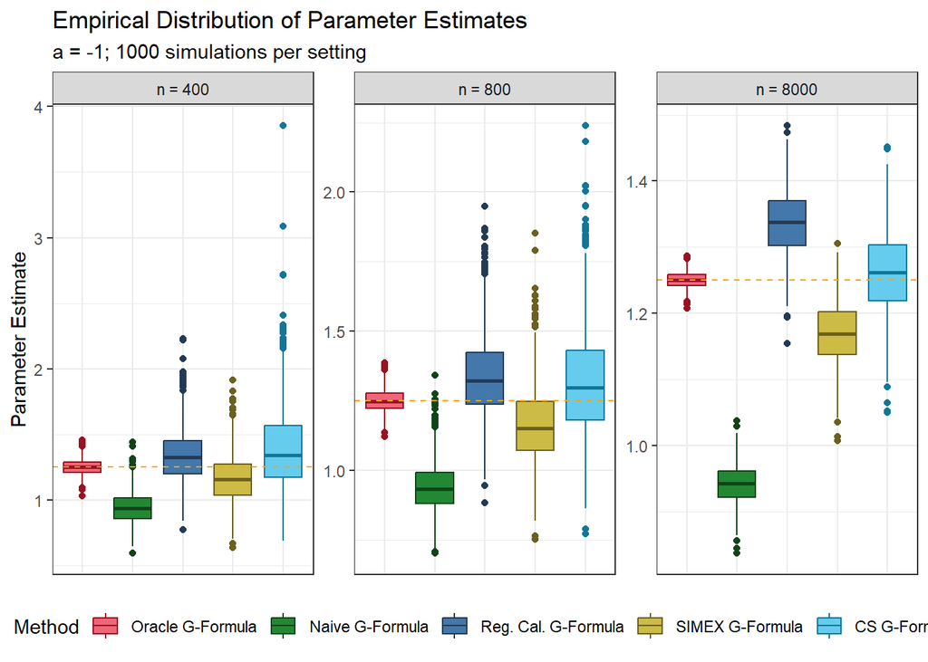

```r
plot.by.a(a. = -1)
```

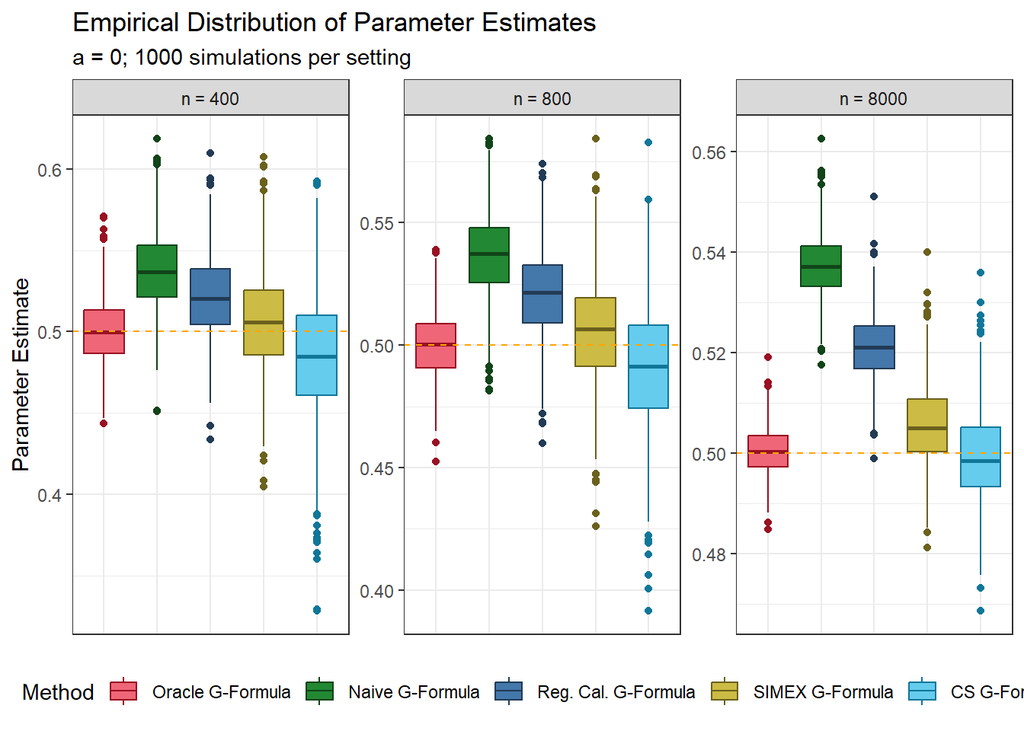

```r
plot.by.a(a. = 0)
```

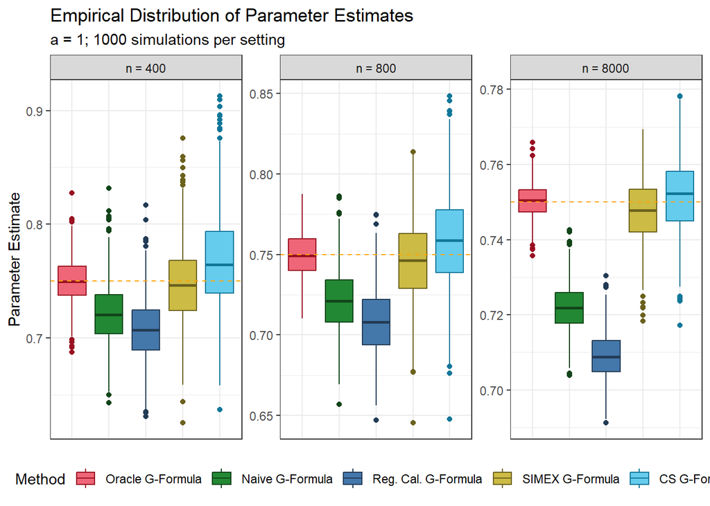

```r
plot.by.a(a. = 1)
```

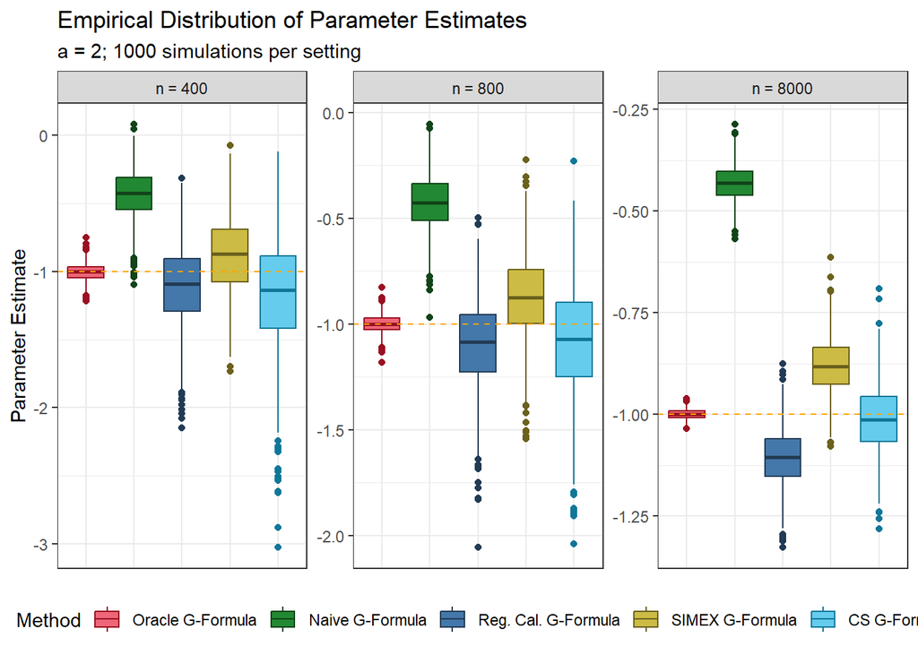

```r
plot.by.a(a. = 2)
```

### Tables of Simulation Results

Below is a table for the primary estimand of interest ($\textrm{E}\{Y(a)\}$ for $a=1$). It includes empirical bias, empirical standard error (ESE), average estimated standard error (ASE), and empirical coverage probability of the 95% CI, for both uncorrected and bias-corrected standard errors.

```r
tbl <- sim.out.long %>%
  filter(a == 1,
         method %in% c("Oracle G-Formula",
                       "Naive G-Formula",
                       "CS G-Formula")) %>%
  group_by(n, method, a) %>%
  summarise(bias = 100 * mean(est - EYa.true, na.rm = T),
            emp.se = 100 * sd(est, na.rm = T),
            est.se = 100 * mean(ste, na.rm = T),
            ci.cov = 100 * mean(ci.cov, na.rm = T),
            bcest.se = 100 * mean(bcs, na.rm = T),
            bcci.cov = 100 * mean(bcci.cov, na.rm = T)) %>%
  left_join(ftc.dat) %>%
  dplyr::select(n, method, bias, emp.se,
                est.se, ci.cov, bcest.se, bcci.cov)

kbl <- tbl %>%
  kable(format = "latex",
        digits = c(0, 0, 1, 1, 1, 1, 1, 1, 1),
        align = c(rep("c", 2),
                  rep("r", 7)),
        booktabs = TRUE,
        linesep = c("", "", "\\addlinespace"),
        escape = FALSE,
        col.names = c("n", "Method",
                      "Bias", "ESE",
                      "ASE", "Cov",
                      "ASE", "Cov")) %>%
  add_header_above(c(" " = 4,
                     "UC" = 2,
                     "BC" = 2)) %>%
  kable_styling("striped") %>%
  row_spec(row = 0, bold = TRUE)

print(kbl)
```

```
## \begin{table}
## \centering
## \begin{tabular}{ccrrrrrr}
## \toprule
## \multicolumn{4}{c}{ } & \multicolumn{2}{c}{UC} & \multicolumn{2}{c}{BC} \\
## \cmidrule(l{3pt}r{3pt}){5-6} \cmidrule(l{3pt}r{3pt}){7-8}
## \textbf{n} & \textbf{Method} & \textbf{Bias} & \textbf{ESE} & \textbf{ASE} & \textbf{Cov} & \textbf{ASE} & \textbf{Cov}\\
## \midrule
## 400 & Oracle G-Formula & 0.0 & 1.9 & 2.0 & 95.0 & 2.1 & 95.6\\
## 400 & Naive G-Formula & -2.9 & 2.5 & 2.4 & 74.4 & 3.3 & 86.1\\
## 400 & CS G-Formula & 1.7 & 4.0 & 3.4 & 89.8 & 7.5 & 97.6\\
## \addlinespace
## 800 & Oracle G-Formula & 0.0 & 1.4 & 1.4 & 95.3 & 1.4 & 95.8\\
## 800 & Naive G-Formula & -2.9 & 1.9 & 1.8 & 59.9 & 2.2 & 70.7\\
## 800 & CS G-Formula & 0.9 & 2.8 & 2.5 & 90.1 & 4.5 & 97.0\\
## \addlinespace
## 8000 & Oracle G-Formula & 0.0 & 0.4 & 0.4 & 94.8 & 0.4 & 94.8\\
## 8000 & Naive G-Formula & -2.8 & 0.6 & 0.6 & 1.0 & 0.7 & 1.4\\
## 8000 & CS G-Formula & 0.2 & 1.0 & 0.9 & 93.2 & 1.0 & 95.3\\
## \bottomrule
## \end{tabular}
## \end{table}
```